# 1.머신러닝 학습의 종류

## **지도학습과 비지도 학습**

- 지도학습(Supervised Learning)

  훈련데이터(train data set)에 타깃(target)또는 레이블(label_이라고 불리는 정답이 포함된 학습방식. 훈련이 끝나면 정답이 포함되지 않은 새로운 데이터 셋(test data set)을 사용하여 정답을 예측하게 함
- 비지도학습(Unsupervised Learning)

  훈련데이터(train data set)가 타깃(target)또는 레이블(label_이라고 불리는 정답이 포함하지 않음. 훈련데이터에 별다른 가이드라인이 없어 기계학습모델이 스스로 학습을 해야 함.

## !우리는 지도학습을 수행할 것임!!

# 2. 시작하기 전에 알아둘 점!

- 머신러닝에서 가장 중요한 것은 **예측의 정확도**를 높이는 것
- 실제 모델을 구현하는 것은 생각보다 어려운 일이 아님. 왜냐하면...구현된 라이브러리를 사용하기 때문
- **사이킷런 라이브러리**
- 정작 중요하고 어려운 것은, 개발한 모델이 실무에 적용될 수 있도록 **예측의 정확도**를 높이는 것 --> 많은 고민과 노력의 과정

# 3. 머신러닝의 전체 단계

1. 머신러닝 라이브러리 불러오기 (ex. 사이킷런)
2. 데이터 불러오기
3. 데이터 전처리 및 시각화/EDA를 통한 변수 설정
4. 훈련 및 검증 데이터의 분리
5. 적합한 머신러닝 알고리즘의 선택하고 학습 (train)
6. 학습된 알고리즘에 검증 데이터에 적용하여 예측 (predict)
7. 예측값과 실제값을 비교해 오차를 측정하여 알고리즘의 성능 평가
8. **3-7단계를 반복**하며 알고리즘의 성능 고도화
9. 실제 예측을 원하는 데이터 (test date)를 적용하여 **최종 예측**!

## 사이킷런으로 시작하는 머신러닝

- 사이킷런(scikit-learn)은 파이썬 머신러닝 라이브러리 중 가장 많이 사용되는 라이브러리
- 최근, 텐서플로(TensorFlow), 케라스(Keras)같은 딥러닝 전문 라이브러리가 각광받지만 파이썬 기반 대표 머닝러닝 라이브러리는 사이킷런!!
- 아나콘다 설치시 사이킷런도 같이 설치되므로 import하여 사용하면 됨

## Step1. 라이브러리 불러오기

```python
#!pip install sklearn
```

```python
import pandas as pd
```

```python
from sklearn.datasets import load_iris
```

## Step2. 데이터 불러오기

```python
iris = load_iris()
```

### iris 데이터셋은 dataframe이 아니기 때문에 .head()를 적용할 수 없음(에러남)

```python
iris.head()
```

```python
iris
```

### iris는 dictionary 자료형 - {Key1:Value1, Key2:Value2, Key3:Value3, ...}

- value는 list형도 가능

```python
iris.keys()
```

## Step3. 데이터 탐색(EDA) 및 변수 설정

- **X (features) - iris.data**
- **y (target) - iris.target**

### feature 데이터 확인 - iris.data

```python
iris.feature_names
```

```python
iris.data
```

### target 데이터 확인 - iris.target

```python
iris.target_names
```

```python
iris.target
```

## Step.4 훈련 및 테스트 데이터 분리

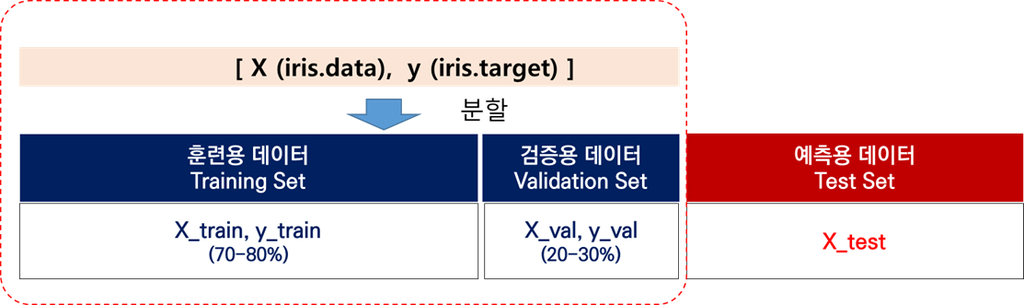

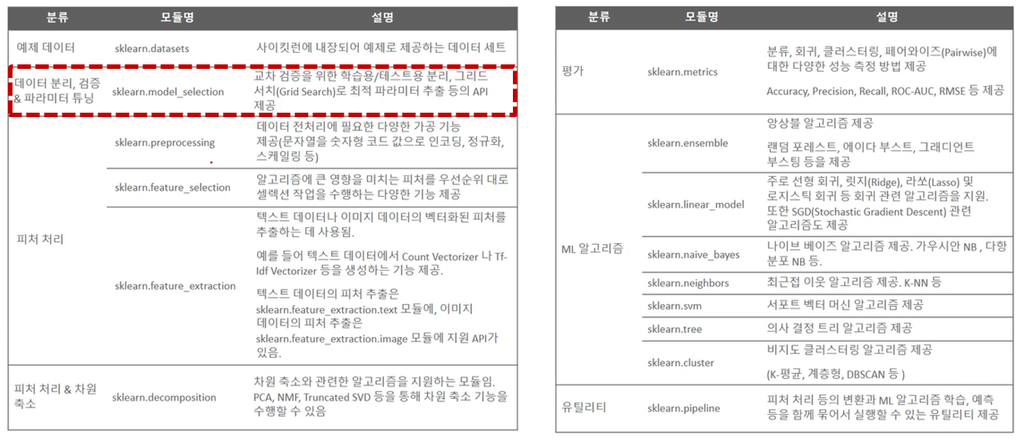

```python
from sklearn.model_selection import train_test_split
```

```python
X_train, X_val, y_train, y_val = train_test_split(iris.data, iris.target,
                                                  test_size=0.3, random_state=0)
```

```python
print('훈련용 X 데이터 사이즈:', X_train.shape)
print('훈련용 y 데이터 사이즈:', y_train.shape)
```

[output not shown]

```python
print('검증용 X 데이터 사이즈:', X_val.shape)
print('검증용 y 데이터 사이즈:', y_val.shape)
```

[output not shown]